# ΜΙΣΤΑ002: Wilcoxon Signed-Rank test

## Wilcoxon Signed-Rank test

The Wilcoxon signed-rank test, which makes use of the sign and the magnitude of the rank of the differences between pairs of measurements, provides an nonparametric alternative test to the paired t-test when the population distribution of the differences is non-normal or for small sample size.

**Assumptions**

- data are paired and the differences come from the same population
- each pair is chosen randomly and independent
- there must be at least 6 pairs of observations - otherwise the test cannot give a significant result irrespective of the difference between the two populations

**The assumption of symmetry**

If you are testing the null hypothesis that the median of the paired differences is zero, then the paired differences must all come from a symmetrical distribution. Note that we do not have to assume that the distributions of the original populations are symmetrical - two very positively skewed distributions that differ only by location will produce a set of paired differences that are symmetrical.

**Steps for conducting the test**

**Step 1. Define the null and alternative hypotheses under study**

**H<sub>0</sub>**: the median difference is equal to zero (md=0).

**H<sub>1</sub>**: the median difference is not equal to zero (md≠0)

**Step 2. Calculate the value of the test statistic specific to H<sub>0</sub>**

The following guidelines should be adhered to when ranking the difference scores, X<sub>before</sub>-X<sub>after</sub> :

- the absolute values of the difference scores are listed in an ascending order and are ranked
- any difference score that equals zero is not ranked
- when there are tied scores present in the data, the average of the ranks involved is assigned to all scores tied for a given rank

The sum of the ranks of the positive differences (T<sub>+</sub>) and the sum of the ranks of the negative differences (T<sub>−</sub>) are calculated. The absolute value of the smaller of the two sum of ranks is defined as the Wilcoxon T test statistic.

**Step 3. Calculate the p value**

Again, the old fashioned way is to compare the Wilcoxon T statistic with the critical values found at tables at the desirable level of significance (usually a=0.05). This method is rarely used anymore.

In practice we usually conduct the Wilcoxon signed rank test using statistical software (e.g. R, SPSS) that automatically provides the p-value.

**Step 4. Interpretation**

Interpretation of the results.

Worked Example

[figure not shown]

A study was run to evaluate the effectiveness of an exercise program in reducing systolic blood pressure. A total of 9 patients enrolled in the study, and their systolic blood pressure was measured. Each patient then participates in an exercise training program where they learned proper techniques and execution of a series of exercises. Patients were instructed to do the exercise program 3 times per week for 6 weeks. After 6 weeks, systolic blood pressures was again measured. The data are shown below.

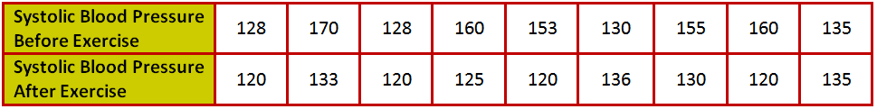

**Step 1. Define the null and alternative hypotheses under study**

**H<sub>0</sub>**: the median difference is equal to zero.

**H<sub>1</sub>**: the median difference scores is not equal to zero

**Step 2. Calculate the value of the test statistic specific to H<sub>0</sub>**

- calculate the differences, Systolic blood pressure before-Systolic blood pressure after. The difference of the 9th patient equals to zero and should be discarded.
- order the remaining eight differences in terms of their absolute magnitude.
- a progressive rank is assigned to each ordered non-zero difference from 1 to 8
- there are two differences of score 8. These are the second and the third ordered absolute difference values, thus their rank is given by (2+3)/2=2.5
- each rank corrected for ties is signed according to the sign of the difference

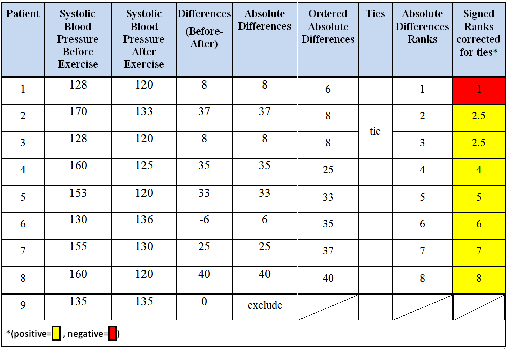

The sum of the ranks of the positive differences is T<sub>+</sub>= 2.5+2.5+4+5+6+7+8=35 (Mean Rank=35/7=5) and the sum of the ranks of the negative differences is T<sub>−</sub>=1 (Mean Rank=1). The Wilcoxon T test statistic is T=1 .

If we run this test in R we will obtain the following

[figure not shown]

**Step 3. Calculate the p value**

R gives a p value of 0.020 < 0.05.

**Step 4. Interpretation**

There is significant evidence at a=0.05 that the systolic blood pressure levels before the exercise program (median (IQR) = 153 (130, 160) ) are higher than after the exercise program (median (IQR)=125 (120, 133)), (p=0.020).

Last modified: Thursday, 23 April 2020, 12:04 PM